# Mangrove Seedling Survivorship Analysis

Sarai Hutchinson

2025-09-06

# Introduction

This analysis examines the effect of different substrate types on the survivorship of red (*Rhizophora mangle*, RHMA) and white (*Laguncularia racemosa*, LARA) mangrove seedlings.

## Treatments

1. **Soil**: Traditional potting soil (control)
2. **Crushed glass**: 100% crushed glass substrate
3. **25% SG**: 3:1 ratio of crushed glass to *Sargassum*
4. **75% SG**: 1:3 ratio of crushed glass to *Sargassum*
5. **100% Sargassum (SG)**: Pure *Sargassum* substrate

## Hypotheses

### Red Mangroves (RHMA)

- **H₀₁**: There is no difference in the survivorship of red mangrove seedlings regardless of treatment.
- **H₁₁**: Red mangroves grown in potting soil will have the greatest survivorship, followed by crushed glass, 25% SG, 75% SG, and 100% Sargassum.

### White Mangroves (LARA)

- **H₀₂**: There is no difference in the survivorship of white mangrove propagules regardless of substrate type.
- **H₁₂**: White mangroves grown in potting soil will exhibit the greatest survivorship, followed by crushed glass, 25% SG, 75% SG, and 100% Sargassum.

# Data Import and Preparation

```r
# Read data
ALLDATA <- read_csv("C:\\Users\\sarai\\OneDrive\\Email attachments\\Documents\\UVI\\Thesis.Work\\SargMangs\\Data/Hutchinson_MonitoringAndIntake_Sites.csv")

# Clean treatment labels
ALLDATA <- ALLDATA %>%
  mutate(
    Treatment_Name = case_when(
      Treatment == "A" ~ "Soil",
      Treatment == "B" ~ "Crushed glass",
      Treatment == "C" ~ "100% Sargassum (SG)",
      Treatment == "D" ~ "75% SG",
      Treatment == "E" ~ "25% SG",
      TRUE ~ as.character(Treatment)
    ),
    Treatment_Name = factor(
      Treatment_Name,
      levels = c("Soil", "Crushed glass", "25% SG", "75% SG", "100% Sargassum (SG)")
    )
  )

# Derive Sargassum indicators
ALLDATA <- ALLDATA %>%
  mutate(
    Sarg_present = if_else(
      Treatment_Name %in% c("75% SG", "25% SG", "100% Sargassum (SG)"),
      1L, 0L
    ),
    Sarg_group = factor(if_else(Sarg_present == 1L, "With Sargassum", "No Sargassum"),
                        levels = c("No Sargassum","With Sargassum")),
    SG_pct = case_when(
      Treatment_Name == "Soil" ~ 0,
      Treatment_Name == "Crushed glass" ~ 0,
      Treatment_Name == "25% SG" ~ 25,
      Treatment_Name == "75% SG" ~ 75,
      Treatment_Name == "100% Sargassum (SG)"~ 100,
      TRUE ~ NA_real_
    )
  )

# Create binary survival variable
ALLDATA_SurvBin <- ALLDATA %>%
  mutate(
    Surv_Bin = ifelse(Survivorship %in% c("A", "DY"), 1, 0),
    Time_Period = factor(Time_Period, levels = c("0", "1", "2", "3", "4", "5", "6")),
    Species = factor(Species)
  )
```

## Quality Control

```r
# Check for resurrection cases (0→1 transitions)
qc_resurrections <- ALLDATA_SurvBin %>%
  mutate(TP_num = as.integer(as.character(Time_Period))) %>%
  arrange(Species, Prop_ID, TP_num) %>%
  group_by(Species, Prop_ID) %>%
  mutate(change = Surv_Bin - lag(Surv_Bin)) %>%
  filter(change == 1 & lag(Surv_Bin) == 0) %>%
  ungroup()

flagged_ids <- qc_resurrections %>% distinct(Species, Prop_ID)

cat("Number of plants with resurrection issues:", nrow(flagged_ids), "\n")
```

```
## Number of plants with resurrection issues: 3
```

```r
# Remove flagged plants
ALLDATA_clean <- ALLDATA_SurvBin %>%
  anti_join(flagged_ids, by = c("Species","Prop_ID"))

cat("Original observations:", nrow(ALLDATA_SurvBin))
```

```
## Original observations: 4200
```

```r
cat("\nClean observations:", nrow(ALLDATA_clean))
```

```
##
## Clean observations: 4179
```

```r
cat("\nObservations removed:", nrow(ALLDATA_SurvBin) - nrow(ALLDATA_clean))
```

```
##
## Observations removed: 21
```

# Exploratory Data Analysis

## Sample Size Overview

```r
# Initial sample sizes
initial_counts <- ALLDATA_clean %>%
  filter(Time_Period == "0") %>%
  group_by(Treatment_Name, Species) %>%
  summarise(n_initial = n()) %>%
  pivot_wider(names_from = Species, values_from = n_initial, values_fill = 0)

initial_counts %>%
  kable(caption = "Initial Sample Sizes by Treatment and Species") %>%
  kable_styling(bootstrap_options = c("striped", "hover"))
```

Initial Sample Sizes by Treatment and Species

| Treatment_Name | LARA | RHMA |
| --- | --- | --- |
| Soil | 58 | 60 |
| Crushed glass | 59 | 60 |
| 25% SG | 60 | 60 |
| 75% SG | 60 | 60 |
| 100% Sargassum (SG) | 60 | 60 |

```r
# Site distribution
site_dist <- ALLDATA_clean %>%
  filter(Time_Period == "0") %>%
  group_by(Site, Treatment_Name) %>%
  summarise(n = n()) %>%
  pivot_wider(names_from = Treatment_Name, values_from = n, values_fill = 0)

site_dist %>%
  kable(caption = "Distribution across Sites") %>%
  kable_styling(bootstrap_options = c("striped", "hover"))
```

Distribution across Sites

| Site | Soil | Crushed glass | 25% SG | 75% SG | 100% Sargassum (SG) |
| --- | --- | --- | --- | --- | --- |
| CP | 20 | 20 | 20 | 20 | 20 |
| MB | 18 | 19 | 20 | 20 | 20 |
| OC | 20 | 20 | 20 | 20 | 20 |
| PR | 40 | 40 | 40 | 40 | 40 |
| VB | 20 | 20 | 20 | 20 | 20 |

## Survival Over Time

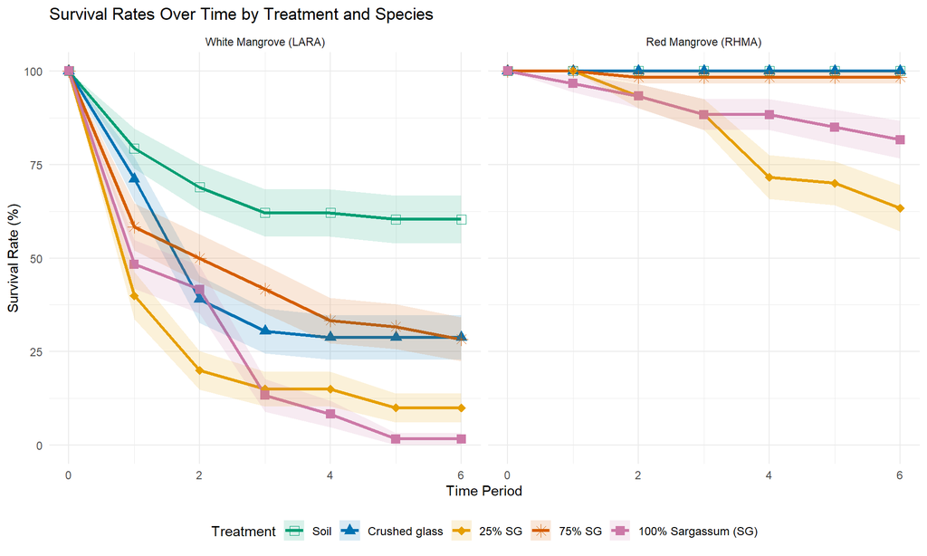

```r
# Calculate survival rates by time period
survival_by_time <- ALLDATA_clean %>%
  group_by(Time_Period, Treatment_Name, Species) %>%
  summarise(
    n_total = n(),
    n_alive = sum(Surv_Bin),
    survival_rate = mean(Surv_Bin) * 100,
    se = sqrt(survival_rate * (100 - survival_rate) / n_total)
  ) %>%
  ungroup()

# Plot survival curves
p_survival_curves <- ggplot(survival_by_time,
             aes(x = as.numeric(as.character(Time_Period)),
                 y = survival_rate,
                 color = Treatment_Name,
                 shape = Treatment_Name,
                 group = Treatment_Name)) +
  geom_line(size = 1.2) +
  geom_point(size = 3) +
  geom_ribbon(aes(ymin = survival_rate - se,
                  ymax = survival_rate + se,
                  fill = Treatment_Name),
              alpha = 0.15,
              linetype = 0) +
  facet_wrap(~ Species, labeller = labeller(Species = c("LARA" = "White Mangrove (LARA)",
                                                         "RHMA" = "Red Mangrove (RHMA)"))) +
  scale_color_manual(values = color_vals) +
  scale_fill_manual(values = color_vals) +
  scale_shape_manual(values = shape_vals) +
  labs(title = "Survival Rates Over Time by Treatment and Species",
       x = "Time Period",
       y = "Survival Rate (%)",
       color = "Treatment",
       shape = "Treatment",
       fill = "Treatment") +
  theme_minimal() +
  theme(legend.position = "bottom",
        legend.text = element_text(size = 9))

print(p_survival_curves)
```

## Final Survival Rates

```r
# Get final survival rates
latest_survival <- survival_by_time %>%
  mutate(Time_Period = parse_number(as.character(Time_Period))) %>%   # TP3 -> 3
  filter(Time_Period == max(Time_Period, na.rm = TRUE)) %>%
  dplyr::select(Treatment_Name, Species, n_total, n_alive, survival_rate, se) %>%
  arrange(Species, desc(survival_rate))

latest_survival %>%
  kable(caption = "Final Survival Rates by Treatment and Species",
        col.names = c("Treatment", "Species", "Total", "Alive", "Survival Rate (%)", "SE"),
        digits = 2) %>%
  kable_styling(bootstrap_options = c("striped", "hover"))
```

Final Survival Rates by Treatment and Species

| Treatment | Species | Total | Alive | Survival Rate (%) | SE |
| --- | --- | --- | --- | --- | --- |
| Soil | LARA | 58 | 35 | 60.34 | 6.42 |
| Crushed glass | LARA | 59 | 17 | 28.81 | 5.90 |
| 75% SG | LARA | 60 | 17 | 28.33 | 5.82 |
| 25% SG | LARA | 60 | 6 | 10.00 | 3.87 |
| 100% Sargassum (SG) | LARA | 60 | 1 | 1.67 | 1.65 |
| Soil | RHMA | 60 | 60 | 100.00 | 0.00 |
| Crushed glass | RHMA | 60 | 60 | 100.00 | 0.00 |
| 75% SG | RHMA | 60 | 59 | 98.33 | 1.65 |
| 100% Sargassum (SG) | RHMA | 60 | 49 | 81.67 | 5.00 |
| 25% SG | RHMA | 60 | 38 | 63.33 | 6.22 |

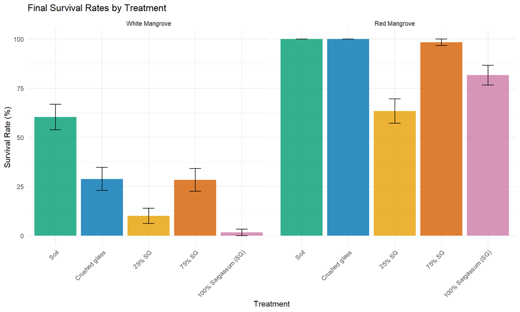

```r
# Bar plot of final survival
p_final_survival <- latest_survival %>%
  ggplot(aes(x = Treatment_Name, y = survival_rate, fill = Treatment_Name)) +
  geom_col(alpha = 0.8) +
  geom_errorbar(aes(ymin = survival_rate - se, ymax = survival_rate + se),
                width = 0.25) +
  facet_wrap(~ Species, labeller = labeller(Species = c("LARA" = "White Mangrove",
                                                        "RHMA" = "Red Mangrove"))) +
  scale_fill_manual(values = color_vals) +
  labs(title = "Final Survival Rates by Treatment",
       x = "Treatment",
       y = "Survival Rate (%)",
       fill = "Treatment") +
  theme_minimal() +
  theme(axis.text.x = element_text(angle = 45, hjust = 1),
        legend.position = "none")

print(p_final_survival)
```

```r
#Step 1: make a dataframe that has all alive plants with survivorship percentages
alive_plants <- ALLDATA_clean %>%
  group_by(Species, Treatment_Name, Replicate, Time_Period) %>%
  summarise(
    alive_n = sum(Surv_Bin == 1, na.rm = TRUE),
    total_n = n(),
    alive_pct = (alive_n / total_n) * 100,
    .groups = "drop"
  )%>%
  arrange(Species, Treatment_Name, Time_Period, Replicate)

# Ensure Time_Period is character only in this pipeline (don’t globally change earlier)
tp_dat <- ALLDATA_clean %>%
  mutate(Time_Period_chr = as.character(Time_Period))

# Alive at TP0 and TP6 only
alive_tp0_6 <- tp_dat %>%
  filter(Time_Period_chr %in% c("0","6"), Surv_Bin == 1)

# IDs alive at BOTH endpoints (species-safe)
survivors_both <- alive_tp0_6 %>%
  distinct(Species, Prop_ID, Time_Period_chr) %>%
  count(Species, Prop_ID, name = "n_tp") %>%
  filter(n_tp == 2) %>%
  dplyr::select(Species, Prop_ID)

# Quick counts per species
survivor_counts <- survivors_both %>%
  count(Species, name = "n_survivors")

print(survivor_counts)
```

```
## # A tibble: 2 × 2
##   Species n_survivors
##   <fct>         <int>
## 1 LARA             76
## 2 RHMA            266
```

```r
# Expect similar to: RHMA ~ 266, LARA ~ 76

# --- Step 3: Separate lists for RHMA and LARA ---------------------------
RHMA_survivors <- survivors_both %>% filter(Species == "RHMA") %>% distinct(Prop_ID)
LARA_survivors <- survivors_both %>% filter(Species == "LARA") %>% distinct(Prop_ID)

# Peek
head(RHMA_survivors); nrow(RHMA_survivors)
```

```
## # A tibble: 6 × 1
##   Prop_ID
##   <chr>
## 1 RA-1
## 2 RA-10
## 3 RA-11
## 4 RA-12
## 5 RA-13
## 6 RA-14
```

```
## [1] 266
```

```r
head(LARA_survivors); nrow(LARA_survivors)
```

```
## # A tibble: 6 × 1
##   Prop_ID
##   <chr>
## 1 LA-10
## 2 LA-14
## 3 LA-15
## 4 LA-16
## 5 LA-17
## 6 LA-18
```

```
## [1] 76
```

```r
# Full histories for just those survivors (still no-flags)
survivor_full_history <- ALLDATA_clean %>%
  inner_join(survivors_both, by = c("Species","Prop_ID"))

# Export the full dataset of ALLDATA (all time periods) to CSV
write.csv(survivor_full_history, "C:\\Users\\sarai\\OneDrive\\Email attachments\\Documents\\UVI\\Thesis.Work\\SargMangs\\OutputData\\survivors_tp0-tp6.csv", row.names = FALSE)
```

## Sargassum Effect

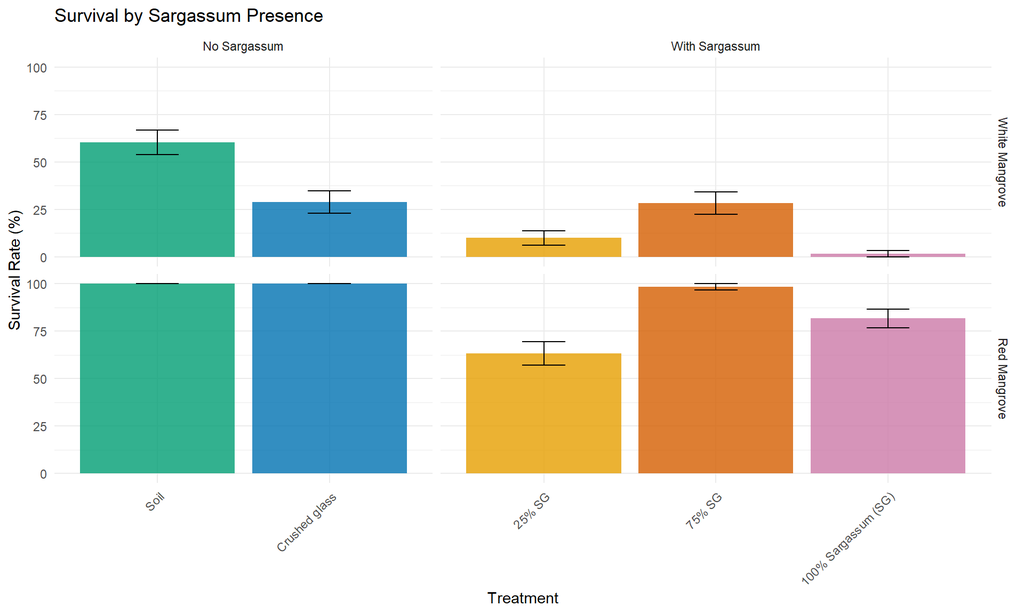

```r
# Compare treatments by Sargassum presence
treatment_comparison <- ALLDATA_clean %>%
  mutate(Time_Period = parse_number(as.character(Time_Period))) %>%
  filter(Time_Period == max(Time_Period)) %>%
  group_by(Treatment_Name, Sarg_group, Species) %>%
  summarise(
    n = n(),
    survival_rate = mean(Surv_Bin) * 100,
    se = sqrt(survival_rate * (100 - survival_rate) / n)
  )

p_sarg_effect <- ggplot(treatment_comparison,
             aes(x = Treatment_Name, y = survival_rate, fill = Treatment_Name)) +
  geom_col(alpha = 0.8) +
  geom_errorbar(aes(ymin = survival_rate - se, ymax = survival_rate + se),
                width = 0.25) +
  facet_grid(Species ~ Sarg_group, scales = "free_x", space = "free_x",
             labeller = labeller(Species = c("RHMA" = "Red Mangrove",
                                            "LARA" = "White Mangrove"))) +
  scale_fill_manual(values = color_vals) +
  labs(title = "Survival by Sargassum Presence",
       x = "Treatment",
       y = "Survival Rate (%)",
       fill = "Treatment") +
  theme_minimal() +
  theme(axis.text.x = element_text(angle = 45, hjust = 1),
        legend.position = "none")

print(p_sarg_effect)
```

```r
# Summary statistics
sarg_summary <- ALLDATA_clean %>%
  mutate(Time_Period = parse_number(as.character(Time_Period))) %>%
  filter(Time_Period == max(Time_Period)) %>%
  group_by(Sarg_group, Species) %>%
  summarise(
    n = n(),
    survival_rate = mean(Surv_Bin) * 100,
    se = sqrt(survival_rate * (100 - survival_rate) / n)
  )

sarg_summary %>%
  kable(caption = "Survival by Sargassum Presence",
        digits = 2) %>%
  kable_styling(bootstrap_options = c("striped", "hover"))
```

Survival by Sargassum Presence

| Sarg_group | Species | n | survival_rate | se |
| --- | --- | --- | --- | --- |
| No Sargassum | LARA | 117 | 44.44 | 4.59 |
| No Sargassum | RHMA | 120 | 100.00 | 0.00 |
| With Sargassum | LARA | 180 | 13.33 | 2.53 |
| With Sargassum | RHMA | 180 | 81.11 | 2.92 |

# Statistical Analysis

## Chi-square Test for Independence

```r
final_data <- ALLDATA_clean %>%
  mutate(Time_Period = parse_number(as.character(Time_Period))) %>%
  filter(Time_Period == max(Time_Period))

# Red mangroves (RHMA)
rhma_data <- final_data %>% filter(Species == "RHMA")
if(nrow(rhma_data) > 0) {
  rhma_contingency <- table(rhma_data$Treatment_Name, rhma_data$Surv_Bin)
  cat("Red Mangroves - Contingency Table:\n")
  print(rhma_contingency)

  rhma_chi <- chisq.test(rhma_contingency)
  cat("\nRed Mangroves - Chi-square Test:\n")
  print(rhma_chi)
}
```

```
## Red Mangroves - Contingency Table:
##
##                        0  1
##   Soil                 0 60
##   Crushed glass        0 60
##   25% SG              22 38
##   75% SG               1 59
##   100% Sargassum (SG) 11 49
##
## Red Mangroves - Chi-square Test:
##
##  Pearson's Chi-squared test
##
## data:  rhma_contingency
## X-squared = 62.163, df = 4, p-value = 1.018e-12
```

```r
# White mangroves (LARA)
lara_data <- final_data %>% filter(Species == "LARA")
if(nrow(lara_data) > 0) {
  lara_contingency <- table(lara_data$Treatment_Name, lara_data$Surv_Bin)
  cat("\n\nWhite Mangroves - Contingency Table:\n")
  print(lara_contingency)

  lara_chi <- chisq.test(lara_contingency)
  cat("\nWhite Mangroves - Chi-square Test:\n")
  print(lara_chi)
}
```

```
##
##
## White Mangroves - Contingency Table:
##
##                        0  1
##   Soil                23 35
##   Crushed glass       42 17
##   25% SG              54  6
##   75% SG              43 17
##   100% Sargassum (SG) 59  1
##
## White Mangroves - Chi-square Test:
##
##  Pearson's Chi-squared test
##
## data:  lara_contingency
## X-squared = 63.045, df = 4, p-value = 6.639e-13
```

## Logistic Regression

```r
# Fit logistic regression model
logit_model <- glm(Surv_Bin ~ Treatment_Name * Species,
                   data = final_data,
                   family = binomial(link = "logit"))

cat("Logistic Regression Model Summary:\n")
```

```
## Logistic Regression Model Summary:
```

```r
summary(logit_model)
```

```
##
## Call:
## glm(formula = Surv_Bin ~ Treatment_Name * Species, family = binomial(link = "logit"),
##     data = final_data)
##
## Coefficients:
##                                                Estimate Std. Error z value
## (Intercept)                                      0.4199     0.2684   1.564
## Treatment_NameCrushed glass                     -1.3243     0.3933  -3.367
## Treatment_Name25% SG                            -2.6171     0.5072  -5.160
## Treatment_Name75% SG                            -1.3478     0.3926  -3.433
## Treatment_Name100% Sargassum (SG)               -4.4974     1.0436  -4.310
## SpeciesRHMA                                     18.1462   842.0691   0.022
## Treatment_NameCrushed glass:SpeciesRHMA          1.3243  1190.8655   0.001
## Treatment_Name25% SG:SpeciesRHMA               -15.4024   842.0692  -0.018
## Treatment_Name75% SG:SpeciesRHMA               -13.1407   842.0697  -0.016
## Treatment_Name100% Sargassum (SG):SpeciesRHMA  -12.5748   842.0697  -0.015
##                                               Pr(>|z|)
## (Intercept)                                   0.117779
## Treatment_NameCrushed glass                   0.000759 ***
## Treatment_Name25% SG                          2.47e-07 ***
## Treatment_Name75% SG                          0.000597 ***
## Treatment_Name100% Sargassum (SG)             1.63e-05 ***
## SpeciesRHMA                                   0.982807
## Treatment_NameCrushed glass:SpeciesRHMA       0.999113
## Treatment_Name25% SG:SpeciesRHMA              0.985407
## Treatment_Name75% SG:SpeciesRHMA              0.987549
## Treatment_Name100% Sargassum (SG):SpeciesRHMA 0.988086
## ---
## Signif. codes:  0 '***' 0.001 '**' 0.01 '*' 0.05 '.' 0.1 ' ' 1
##
## (Dispersion parameter for binomial family taken to be 1)
##
##     Null deviance: 814.89  on 596  degrees of freedom
## Residual deviance: 415.67  on 587  degrees of freedom
## AIC: 435.67
##
## Number of Fisher Scoring iterations: 17
```

```r
cat("\n\nAnalysis of Deviance:\n")
```

```
##
##
## Analysis of Deviance:
```

```r
anova(logit_model, test = "Chisq")
```

```
## Analysis of Deviance Table
##
## Model: binomial, link: logit
##
## Response: Surv_Bin
##
## Terms added sequentially (first to last)
##
##
##                        Df Deviance Resid. Df Resid. Dev  Pr(>Chi)
## NULL                                     596     814.89
## Treatment_Name          4    65.52       592     749.38 2.001e-13 ***
## Species                 1   319.11       591     430.27 < 2.2e-16 ***
## Treatment_Name:Species  4    14.59       587     415.67  0.005621 **
## ---
## Signif. codes:  0 '***' 0.001 '**' 0.01 '*' 0.05 '.' 0.1 ' ' 1
```

## Post-hoc Comparisons

```r
# Estimated marginal means
emmeans_survival <- emmeans(logit_model, ~ Treatment_Name | Species, type = "response")
cat("Estimated Marginal Means (Survival Probability):\n")
```

```
## Estimated Marginal Means (Survival Probability):
```

```r
print(summary(emmeans_survival))
```

```
## Species = LARA:
##  Treatment_Name           prob       SE  df asymp.LCL asymp.UCL
##  Soil                0.6034483 6.42e-02 Inf 0.4734647  0.720300
##  Crushed glass       0.2881356 5.90e-02 Inf 0.1872671  0.415556
##  25% SG              0.1000000 3.87e-02 Inf 0.0456225  0.205251
##  75% SG              0.2833333 5.82e-02 Inf 0.1839958  0.409395
##  100% Sargassum (SG) 0.0166667 1.65e-02 Inf 0.0023429  0.108996
##
## Species = RHMA:
##  Treatment_Name           prob       SE  df asymp.LCL asymp.UCL
##  Soil                1.0000000 7.28e-06 Inf 0.0000000  1.000000
##  Crushed glass       1.0000000 7.28e-06 Inf 0.0000000  1.000000
##  25% SG              0.6333333 6.22e-02 Inf 0.5053672  0.744904
##  75% SG              0.9833333 1.65e-02 Inf 0.8910036  0.997657
##  100% Sargassum (SG) 0.8166667 5.00e-02 Inf 0.6984648  0.895468
##
## Confidence level used: 0.95
## Intervals are back-transformed from the logit scale
```

```r
# Pairwise within each species
pairs_by <- pairs(emmeans_survival, by = "Species", adjust = "tukey")

# Print both species nicely
summary(pairs_by)                    # log-odds (β) differences
```

```
## Species = LARA:
##  contrast                            odds.ratio       SE  df null z.ratio
##  Soil / Crushed glass                         4 1.00e+00 Inf    1   3.367
##  Soil / 25% SG                               14 7.00e+00 Inf    1   5.160
##  Soil / 75% SG                                4 2.00e+00 Inf    1   3.433
##  Soil / 100% Sargassum (SG)                  90 9.40e+01 Inf    1   4.310
##  Crushed glass / 25% SG                       4 2.00e+00 Inf    1   2.498
##  Crushed glass / 75% SG                       1 0.00e+00 Inf    1   0.058
##  Crushed glass / 100% Sargassum (SG)         24 2.50e+01 Inf    1   3.026
##  25% SG / 75% SG                              0 0.00e+00 Inf    1  -2.455
##  25% SG / 100% Sargassum (SG)                 7 7.00e+00 Inf    1   1.715
##  75% SG / 100% Sargassum (SG)                23 2.40e+01 Inf    1   3.004
##  p.value
##   0.0068
##   <.0001
##   0.0054
##   0.0002
##   0.0910
##   1.0000
##   0.0209
##   0.1011
##   0.4246
##   0.0224
##
## Species = RHMA:
##  contrast                            odds.ratio       SE  df null z.ratio
##  Soil / Crushed glass                         1 1.19e+03 Inf    1   0.000
##  Soil / 25% SG                         66954564 5.64e+10 Inf    1   0.021
##  Soil / 75% SG                          1960149 1.65e+09 Inf    1   0.017
##  Soil / 100% Sargassum (SG)            25961974 2.19e+10 Inf    1   0.020
##  Crushed glass / 25% SG                66954564 5.64e+10 Inf    1   0.021
##  Crushed glass / 75% SG                 1960149 1.65e+09 Inf    1   0.017
##  Crushed glass / 100% Sargassum (SG)   25961974 2.19e+10 Inf    1   0.020
##  25% SG / 75% SG                              0 0.00e+00 Inf    1  -3.384
##  25% SG / 100% Sargassum (SG)                 0 0.00e+00 Inf    1  -2.214
##  75% SG / 100% Sargassum (SG)                13 1.40e+01 Inf    1   2.432
##  p.value
##   1.0000
##   1.0000
##   1.0000
##   1.0000
##   1.0000
##   1.0000
##   1.0000
##   0.0064
##   0.1744
##   0.1068
##
## P value adjustment: tukey method for comparing a family of 5 estimates
## Tests are performed on the log odds ratio scale
```

```r
summary(pairs_by, exp = TRUE)        # odds ratios (recommended)
```

```
## Species = LARA:
##  contrast                            odds.ratio       SE  df null z.ratio
##  Soil / Crushed glass                         4 1.00e+00 Inf    1   3.367
##  Soil / 25% SG                               14 7.00e+00 Inf    1   5.160
##  Soil / 75% SG                                4 2.00e+00 Inf    1   3.433
##  Soil / 100% Sargassum (SG)                  90 9.40e+01 Inf    1   4.310
##  Crushed glass / 25% SG                       4 2.00e+00 Inf    1   2.498
##  Crushed glass / 75% SG                       1 0.00e+00 Inf    1   0.058
##  Crushed glass / 100% Sargassum (SG)         24 2.50e+01 Inf    1   3.026
##  25% SG / 75% SG                              0 0.00e+00 Inf    1  -2.455
##  25% SG / 100% Sargassum (SG)                 7 7.00e+00 Inf    1   1.715
##  75% SG / 100% Sargassum (SG)                23 2.40e+01 Inf    1   3.004
##  p.value
##   0.0068
##   <.0001
##   0.0054
##   0.0002
##   0.0910
##   1.0000
##   0.0209
##   0.1011
##   0.4246
##   0.0224
##
## Species = RHMA:
##  contrast                            odds.ratio       SE  df null z.ratio
##  Soil / Crushed glass                         1 1.19e+03 Inf    1   0.000
##  Soil / 25% SG                         66954564 5.64e+10 Inf    1   0.021
##  Soil / 75% SG                          1960149 1.65e+09 Inf    1   0.017
##  Soil / 100% Sargassum (SG)            25961974 2.19e+10 Inf    1   0.020
##  Crushed glass / 25% SG                66954564 5.64e+10 Inf    1   0.021
##  Crushed glass / 75% SG                 1960149 1.65e+09 Inf    1   0.017
##  Crushed glass / 100% Sargassum (SG)   25961974 2.19e+10 Inf    1   0.020
##  25% SG / 75% SG                              0 0.00e+00 Inf    1  -3.384
##  25% SG / 100% Sargassum (SG)                 0 0.00e+00 Inf    1  -2.214
##  75% SG / 100% Sargassum (SG)                13 1.40e+01 Inf    1   2.432
##  p.value
##   1.0000
##   1.0000
##   1.0000
##   1.0000
##   1.0000
##   1.0000
##   1.0000
##   0.0064
##   0.1744
##   0.1068
##
## P value adjustment: tukey method for comparing a family of 5 estimates
## Tests are performed on the log odds ratio scale
```

```r
#If you want data frames (easy to filter/report)
pairs_df      <- as.data.frame(summary(pairs_by))
pairs_df_or   <- as.data.frame(summary(pairs_by, exp = TRUE))  # with ORs

# Separate tables:
pairs_lara <- subset(pairs_df_or, Species == "LARA")
pairs_rhma <- subset(pairs_df_or, Species == "RHMA")
```

Re-fit the model using Firth logistif since there was complete separation due to all the soil and crushed glass surviving for RHMA. This led to differences in the other 3 not being as apparent though.

```r
library(logistf)
library(emmeans)

analyze_species_survival <- function(data, species_name) {
  # Filter for chosen species
  dat_sp <- subset(data, Species == species_name)

  # Fit Firth logistic regression with treatment only
  firth_mod <- logistf(Surv_Bin ~ Treatment_Name, data = dat_sp)

  # Model summary
  cat("\n===== Results for", species_name, "=====\n")
  print(summary(firth_mod))

  # Estimated marginal means (survival probabilities)
  emm <- emmeans(firth_mod, ~ Treatment_Name, type = "response")
  cat("\nEstimated Survival Probabilities:\n")
  print(summary(emm))

  # Pairwise comparisons among treatments
  pairs_res <- pairs(emm, adjust = "tukey")
  cat("\nPairwise Comparisons:\n")
  print(summary(pairs_res, exp = TRUE))   # odds ratios

  # Return list of objects in case you want to reuse them
  return(list(
    model = firth_mod,
    emmeans = emm,
    pairs = pairs_res
  ))
}

# White mangroves
lara_results <- analyze_species_survival(final_data, "LARA")
```

```
##
## ===== Results for LARA =====
## logistf(formula = Surv_Bin ~ Treatment_Name, data = dat_sp)
##
## Model fitted by Penalized ML
## Coefficients:
##                                         coef  se(coef) lower 0.95 upper 0.95
## (Intercept)                        0.4125323 0.2659365 -0.1024181  0.9460255
## Treatment_NameCrushed glass       -1.2998355 0.3890944 -2.0808326 -0.5505331
## Treatment_Name25% SG              -2.5389308 0.4928661 -3.5818661 -1.6273063
## Treatment_Name75% SG              -1.3230923 0.3883987 -2.1028822 -0.5753239
## Treatment_Name100% Sargassum (SG) -4.0930435 0.8684443 -6.3170069 -2.6762992
##                                      Chisq            p method
## (Intercept)                        2.45779 1.169432e-01      2
## Treatment_NameCrushed glass       11.77598 6.000007e-04      2
## Treatment_Name25% SG              34.66431 3.917483e-09      2
## Treatment_Name75% SG              12.26531 4.614570e-04      2
## Treatment_Name100% Sargassum (SG) 54.84956 1.301181e-13      2
##
## Method: 1-Wald, 2-Profile penalized log-likelihood, 3-None
##
## Likelihood ratio test=65.72676 on 4 df, p=1.808553e-13, n=297
## Wald test = 68.59075 on 4 df, p = 4.507505e-14logistf(formula = Surv_Bin ~ Treatment_Name, data = dat_sp)
## Model fitted by Penalized ML
## Confidence intervals and p-values by Profile Likelihood
##
## Coefficients:
##                       (Intercept)       Treatment_NameCrushed glass
##                         0.4125323                        -1.2998355
##              Treatment_Name25% SG              Treatment_Name75% SG
##                        -2.5389308                        -1.3230923
## Treatment_Name100% Sargassum (SG)
##                        -4.0930435
##
## Likelihood ratio test=65.72676 on 4 df, p=1.808553e-13, n=297
##
##
## Estimated Survival Probabilities:
##  Treatment_Name        prob     SE  df lower.CL upper.CL
##  Soil                0.6017 0.0637 292  0.47231    0.718
```

[output cut: 8 more lines]

```
## Pairwise Comparisons:
##  contrast                            odds.ratio     SE  df null t.ratio p.value
##  Soil / Crushed glass                     3.669  1.430 292    1   3.341  0.0083
##  Soil / 25% SG                           12.666  6.240 292    1   5.151  <.0001
##  Soil / 75% SG                            3.755  1.460 292    1   3.407  0.0067
##  Soil / 100% Sargassum (SG)              59.922 52.000 292    1   4.713  <.0001
##  Crushed glass / 25% SG                   3.452  1.740 292    1   2.464  0.1018
##  Crushed glass / 75% SG                   1.024  0.410 292    1   0.058  1.0000
##  Crushed glass / 100% Sargassum (SG)     16.333 14.300 292    1   3.195  0.0133
##  25% SG / 75% SG                          0.296  0.149 292    1  -2.420  0.1127
##  25% SG / 100% Sargassum (SG)             4.731  4.380 292    1   1.680  0.4479
##  75% SG / 100% Sargassum (SG)            15.958 13.900 292    1   3.170  0.0145
##
## P value adjustment: tukey method for comparing a family of 5 estimates
## Tests are performed on the log odds ratio scale
```

```r
# Red mangroves
rhma_results <- analyze_species_survival(final_data, "RHMA")
```

```
##
## ===== Results for RHMA =====
## logistf(formula = Surv_Bin ~ Treatment_Name, data = dat_sp)
##
## Model fitted by Penalized ML
## Coefficients:
##                                            coef se(coef) lower 0.95 upper 0.95
## (Intercept)                        4.795791e+00 1.420045   2.862264   9.633379
## Treatment_NameCrushed glass        5.897928e-15 2.008247  -5.225110   5.225110
## Treatment_Name25% SG              -4.258648e+00 1.444627  -9.113646  -2.229864
## Treatment_Name75% SG              -1.115279e+00 1.643168  -6.106598   1.836020
## Treatment_Name100% Sargassum (SG) -3.336165e+00 1.457288  -8.200039  -1.255346
##                                        Chisq            p method
## (Intercept)                              Inf 0.000000e+00      2
## Treatment_NameCrushed glass        0.0000000 1.000000e+00      2
## Treatment_Name25% SG              31.9970213 1.544092e-08      2
## Treatment_Name75% SG               0.5315816 4.659427e-01      2
## Treatment_Name100% Sargassum (SG) 13.5804481 2.285537e-04      2
##
## Method: 1-Wald, 2-Profile penalized log-likelihood, 3-None
##
## Likelihood ratio test=58.37152 on 4 df, p=6.376566e-12, n=300
## Wald test = 66.60976 on 4 df, p = 1.177947e-13logistf(formula = Surv_Bin ~ Treatment_Name, data = dat_sp)
## Model fitted by Penalized ML
## Confidence intervals and p-values by Profile Likelihood
##
## Coefficients:
##                       (Intercept)       Treatment_NameCrushed glass
##                      4.795791e+00                      5.897928e-15
##              Treatment_Name25% SG              Treatment_Name75% SG
##                     -4.258648e+00                     -1.115279e+00
## Treatment_Name100% Sargassum (SG)
##                     -3.336165e+00
##
## Likelihood ratio test=58.37152 on 4 df, p=6.376566e-12, n=300
##
##
## Estimated Survival Probabilities:
##  Treatment_Name       prob     SE  df lower.CL upper.CL
##  Soil                0.992 0.0115 295    0.881    0.999
```

[output cut: 19 more lines]

```
##  75% SG / 100% Sargassum (SG)            9.2155   8.1900 295    1   2.498
##  p.value
##   1.0000
##   0.0283
##   0.9609
##   0.1512
##   0.0283
##   0.9609
##   0.1512
##   0.0032
##   0.1867
##   0.0939
##
## P value adjustment: tukey method for comparing a family of 5 estimates
## Tests are performed on the log odds ratio scale
```

## Mixed Effects Model

This code has the impact of the complete separation caused by the RHMA survivorship

```r
# Account for repeated measures and site effects
ALLDATA_model <- ALLDATA_clean %>%
  mutate(Time_num = as.numeric(as.character(Time_Period)))

# Fit mixed effects logistic regression
mixed_model <- glmer(Surv_Bin ~ Treatment_Name +
                     (1 | Prop_ID) + (1 | Site),
                     data = ALLDATA_model,
                     family = binomial,
                     control = glmerControl(optimizer = "bobyqa"))

cat("Mixed Effects Model Summary:\n")
```

```
## Mixed Effects Model Summary:
```

```r
summary(mixed_model)
```

```
## Generalized linear mixed model fit by maximum likelihood (Laplace
##   Approximation) [glmerMod]
##  Family: binomial  ( logit )
## Formula: Surv_Bin ~ Treatment_Name + (1 | Prop_ID) + (1 | Site)
##    Data: ALLDATA_model
## Control: glmerControl(optimizer = "bobyqa")
##
##       AIC       BIC    logLik -2*log(L)  df.resid
##    2973.9    3018.3   -1480.0    2959.9      4172
##
## Scaled residuals:
##      Min       1Q   Median       3Q      Max
## -2.97090 -0.41365  0.07503  0.17974  2.52257
##
## Random effects:
##  Groups  Name        Variance Std.Dev.
##  Prop_ID (Intercept) 5.066    2.251
##  Site    (Intercept) 7.234    2.690
## Number of obs: 4179, groups:  Prop_ID, 597; Site, 5
##
## Fixed effects:
##                                   Estimate Std. Error z value Pr(>|z|)
## (Intercept)                         4.7763     1.2672   3.769 0.000164 ***
## Treatment_NameCrushed glass        -1.5860     0.4413  -3.594 0.000326 ***
## Treatment_Name25% SG               -3.6926     0.4379  -8.432  < 2e-16 ***
## Treatment_Name75% SG               -1.6590     0.4392  -3.777 0.000159 ***
## Treatment_Name100% Sargassum (SG)  -3.2422     0.4355  -7.444 9.78e-14 ***
## ---
## Signif. codes:  0 '***' 0.001 '**' 0.01 '*' 0.05 '.' 0.1 ' ' 1
##
## Correlation of Fixed Effects:
##             (Intr) Tr_NCg T_N25S T_N75S
## Trtmnt_NmCg -0.217
## Trtm_N25%SG -0.253  0.606
## Trtm_N75%SG -0.221  0.581  0.616
## T_N100%S(SG -0.246  0.603  0.664  0.612
```

```r
cat("\n\nFixed Effects Significance:\n")
```

```
##
##
## Fixed Effects Significance:
```

```r
anova(mixed_model)
```

```
## Analysis of Variance Table
##                npar Sum Sq Mean Sq F value
## Treatment_Name    4 99.236  24.809  24.809
```

Re-run but separate the species

```r
# --- White mangroves ---
lara_data <- subset(ALLDATA_model, Species == "LARA")

glmer_lara <- glmer(Surv_Bin ~ Treatment_Name +
                      (1 | Prop_ID) + (1 | Site),
                    data = lara_data,
                    family = binomial,
                    control = glmerControl(optimizer = "bobyqa"))

summary(glmer_lara)
```

```
## Generalized linear mixed model fit by maximum likelihood (Laplace
##   Approximation) [glmerMod]
##  Family: binomial  ( logit )
## Formula: Surv_Bin ~ Treatment_Name + (1 | Prop_ID) + (1 | Site)
##    Data: lara_data
## Control: glmerControl(optimizer = "bobyqa")
##
##       AIC       BIC    logLik -2*log(L)  df.resid
##    2300.8    2340.3   -1143.4    2286.8      2072
##
## Scaled residuals:
##     Min      1Q  Median      3Q     Max
## -2.0531 -0.5512 -0.4326  0.3576  2.3216
##
## Random effects:
##  Groups  Name        Variance Std.Dev.
##  Prop_ID (Intercept) 2.7018   1.6437
##  Site    (Intercept) 0.1725   0.4153
## Number of obs: 2079, groups:  Prop_ID, 297; Site, 3
##
## Fixed effects:
##                                   Estimate Std. Error z value Pr(>|z|)
## (Intercept)                         1.6103     0.3751   4.294 1.76e-05 ***
## Treatment_NameCrushed glass        -1.6347     0.3801  -4.301 1.70e-05 ***
## Treatment_Name25% SG               -2.6810     0.3835  -6.990 2.74e-12 ***
## Treatment_Name75% SG               -1.5443     0.3794  -4.070 4.70e-05 ***
## Treatment_Name100% Sargassum (SG)  -2.6507     0.3821  -6.938 3.99e-12 ***
## ---
## Signif. codes:  0 '***' 0.001 '**' 0.01 '*' 0.05 '.' 0.1 ' ' 1
##
## Correlation of Fixed Effects:
##             (Intr) Tr_NCg T_N25S T_N75S
## Trtmnt_NmCg -0.572
## Trtm_N25%SG -0.582  0.561
## Trtm_N75%SG -0.574  0.558  0.564
## T_N100%S(SG -0.586  0.565  0.577  0.568
```

```r
emm_lara <- emmeans(glmer_lara, ~ Treatment_Name, type = "response")
summary(emm_lara)
```

```
##  Treatment_Name       prob     SE  df asymp.LCL asymp.UCL
##  Soil                0.833 0.0521 Inf     0.706     0.913
##  Crushed glass       0.494 0.0873 Inf     0.330     0.659
##  25% SG              0.255 0.0660 Inf     0.148     0.404
##  75% SG              0.517 0.0869 Inf     0.351     0.679
##  100% Sargassum (SG) 0.261 0.0664 Inf     0.152     0.410
##
## Confidence level used: 0.95
## Intervals are back-transformed from the logit scale
```

```r
pairs(emm_lara, adjust = "tukey")
```

```
##  contrast                            odds.ratio    SE  df null z.ratio p.value
##  Soil / Crushed glass                     5.128 1.950 Inf    1   4.301  0.0002
##  Soil / 25% SG                           14.600 5.600 Inf    1   6.990  <.0001
##  Soil / 75% SG                            4.685 1.780 Inf    1   4.070  0.0005
##  Soil / 100% Sargassum (SG)              14.164 5.410 Inf    1   6.938  <.0001
##  Crushed glass / 25% SG                   2.847 1.020 Inf    1   2.926  0.0284
##  Crushed glass / 75% SG                   0.914 0.326 Inf    1  -0.253  0.9991
##  Crushed glass / 100% Sargassum (SG)      2.762 0.981 Inf    1   2.860  0.0344
##  25% SG / 75% SG                          0.321 0.114 Inf    1  -3.191  0.0124
##  25% SG / 100% Sargassum (SG)             0.970 0.342 Inf    1  -0.086  1.0000
##  75% SG / 100% Sargassum (SG)             3.024 1.070 Inf    1   3.127  0.0152
##
## P value adjustment: tukey method for comparing a family of 5 estimates
## Tests are performed on the log odds ratio scale
```

```r
# --- Red mangroves ---
rhma_data <- subset(ALLDATA_model, Species == "RHMA")

glmer_rhma <- glmer(Surv_Bin ~ Treatment_Name +
                      (1 | Prop_ID) + (1 | Site),
                    data = rhma_data,
                    family = binomial,
                    control = glmerControl(optimizer = "bobyqa"))

summary(glmer_rhma)
```

```
## Generalized linear mixed model fit by maximum likelihood (Laplace
##   Approximation) [glmerMod]
##  Family: binomial  ( logit )
## Formula: Surv_Bin ~ Treatment_Name + (1 | Prop_ID) + (1 | Site)
##    Data: rhma_data
## Control: glmerControl(optimizer = "bobyqa")
##
##       AIC       BIC    logLik -2*log(L)  df.resid
##     491.2     530.7    -238.6     477.2      2093
##
## Scaled residuals:
##      Min       1Q   Median       3Q      Max
## -2.72435  0.00000  0.00695  0.02292  2.11614
##
## Random effects:
##  Groups  Name        Variance  Std.Dev.
##  Prop_ID (Intercept) 3.215e+01 5.670e+00
##  Site    (Intercept) 3.483e-14 1.866e-07
## Number of obs: 2100, groups:  Prop_ID, 300; Site, 3
##
## Fixed effects:
##                                    Estimate Std. Error z value Pr(>|z|)
## (Intercept)                          27.969  57809.276       0        1
## Treatment_NameCrushed glass          -5.266  57958.293       0        1
## Treatment_Name25% SG                -21.762  57809.276       0        1
## Treatment_Name75% SG                -18.042  57809.277       0        1
## Treatment_Name100% Sargassum (SG)   -20.536  57809.276       0        1
##
## Correlation of Fixed Effects:
##             (Intr) Tr_NCg T_N25S T_N75S
## Trtmnt_NmCg -0.997
## Trtm_N25%SG -1.000  0.997
## Trtm_N75%SG -1.000  0.997  1.000
## T_N100%S(SG -1.000  0.997  1.000  1.000
## optimizer (bobyqa) convergence code: 0 (OK)
## boundary (singular) fit: see help('isSingular')
```

```r
emm_rhma <- emmeans(glmer_rhma, ~ Treatment_Name, type = "response")
summary(emm_rhma)
```

```
##  Treatment_Name           prob       SE  df asymp.LCL asymp.UCL
##  Soil                1.0000000 4.12e-08 Inf 0.0000000 1.0000000
##  Crushed glass       1.0000000 5.73e-07 Inf 0.0000000 1.0000000
##  25% SG              0.9979898 2.05e-03 Inf 0.9853225 0.9997277
##  75% SG              0.9999512 2.18e-04 Inf 0.7652128 1.0000000
##  100% Sargassum (SG) 0.9994091 8.40e-04 Inf 0.9904919 0.9999636
##
## Confidence level used: 0.95
## Intervals are back-transformed from the logit scale
```

```r
pairs(emm_rhma, adjust = "tukey")
```

```
##  contrast                            odds.ratio       SE  df null z.ratio
##  Soil / Crushed glass                  1.94e+02 1.12e+07 Inf    1   0.000
##  Soil / 25% SG                         2.83e+09 1.63e+14 Inf    1   0.000
##  Soil / 75% SG                         6.85e+07 3.96e+12 Inf    1   0.000
##  Soil / 100% Sargassum (SG)            8.29e+08 4.79e+13 Inf    1   0.000
##  Crushed glass / 25% SG                1.46e+07 6.06e+10 Inf    1   0.004
##  Crushed glass / 75% SG                3.54e+05 1.47e+09 Inf    1   0.003
##  Crushed glass / 100% Sargassum (SG)   4.28e+06 1.78e+10 Inf    1   0.004
##  25% SG / 75% SG                       0.00e+00 0.00e+00 Inf    1  -0.813
##  25% SG / 100% Sargassum (SG)          0.00e+00 1.00e+00 Inf    1  -0.700
##  75% SG / 100% Sargassum (SG)          1.20e+01 5.70e+01 Inf    1   0.533
##  p.value
##   1.0000
##   1.0000
##   1.0000
##   1.0000
##   1.0000
##   1.0000
##   1.0000
##   0.9269
##   0.9565
##   0.9840
##
## P value adjustment: tukey method for comparing a family of 5 estimates
## Tests are performed on the log odds ratio scale
```

## Sargassum Gradient Analysis

```r
# Analyze Sargassum as continuous predictor
gradient_model <- glm(Surv_Bin ~ SG_pct * Species,
                      data = final_data,
                      family = binomial)

cat("Sargassum Gradient Model:\n")
```

```
## Sargassum Gradient Model:
```

```r
summary(gradient_model)
```

```
##
## Call:
## glm(formula = Surv_Bin ~ SG_pct * Species, family = binomial,
##     data = final_data)
##
## Coefficients:
##                     Estimate Std. Error z value Pr(>|z|)
## (Intercept)        -0.435028   0.171924  -2.530   0.0114 *
## SG_pct             -0.019439   0.004059  -4.789 1.67e-06 ***
## SpeciesRHMA         2.811785   0.332304   8.461  < 2e-16 ***
## SG_pct:SpeciesRHMA  0.012277   0.005999   2.046   0.0407 *
## ---
## Signif. codes:  0 '***' 0.001 '**' 0.01 '*' 0.05 '.' 0.1 ' ' 1
##
## (Dispersion parameter for binomial family taken to be 1)
##
##     Null deviance: 814.89  on 596  degrees of freedom
## Residual deviance: 519.32  on 593  degrees of freedom
## AIC: 527.32
##
## Number of Fisher Scoring iterations: 5
```

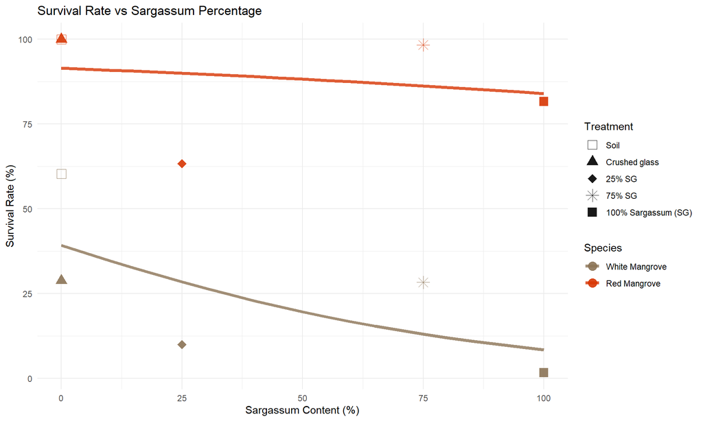

```r
# Visualize gradient effect
gradient_pred <- expand.grid(
  SG_pct = seq(0, 100, by = 5),
  Species = unique(final_data$Species)
)

gradient_pred$pred_survival <- predict(gradient_model,
                                       newdata = gradient_pred,
                                       type = "response")

obs_data <- final_data %>%
  group_by(SG_pct, Species, Treatment_Name) %>%
  summarise(obs_survival = mean(Surv_Bin) * 100) %>%
  ungroup()

p_gradient <- ggplot(gradient_pred, aes(x = SG_pct, y = pred_survival * 100)) +
  geom_line(aes(color = Species), size = 1.5, alpha = 0.8) +
  geom_point(data = obs_data,
             aes(y = obs_survival, color = Species, shape = Treatment_Name),
             size = 4, alpha = 0.9) +
  scale_color_manual(values = c("RHMA" = "#D73502", "LARA" = "#8B7355"),
                    labels = c("RHMA" = "Red Mangrove", "LARA" = "White Mangrove")) +
  scale_shape_manual(values = shape_vals) +
  labs(title = "Survival Rate vs Sargassum Percentage",
       x = "Sargassum Content (%)",
       y = "Survival Rate (%)",
       color = "Species",
       shape = "Treatment") +
  theme_minimal() +
  theme(legend.position = "right")

print(p_gradient)
```

## Kaplan-Meier Survival Analysis

I feel like this is important to show how quickly they died across treatments. However, I need some more clarification on this.

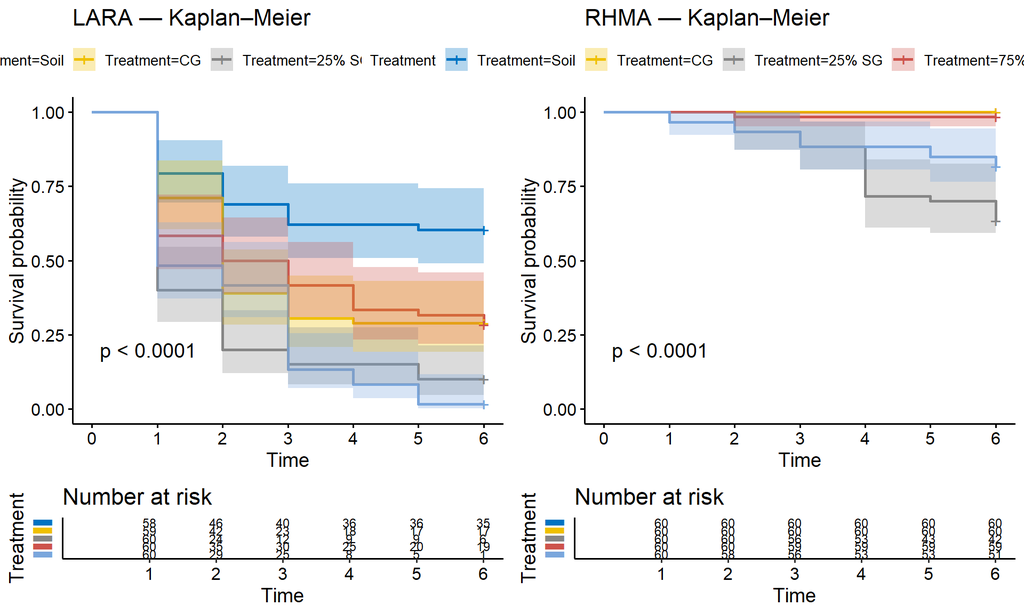

```r
# Prepare data for survival analysis
surv_data <- ALLDATA_clean %>%
  group_by(Species, Prop_ID, Treatment_Name) %>%
  summarise(
    last_alive = max(as.numeric(as.character(Time_Period[Surv_Bin == 1])), na.rm = TRUE),
    final_status = ifelse(any(Surv_Bin == 0), 1, 0),  # 1 = died, 0 = censored
    survival_time = ifelse(final_status == 1,
                          min(as.numeric(as.character(Time_Period[Surv_Bin == 0])), na.rm = TRUE),
                          max(as.numeric(as.character(Time_Period))))
  ) %>%
  ungroup()

# # Create survival object
# surv_obj <- Surv(time = surv_data$survival_time, event = surv_data$final_status)
#
# # Fit survival curves
# fit <- survfit(surv_obj ~ Treatment_Name + Species, data = surv_data)
#
# # Plot Kaplan-Meier curves
# ggsurvplot(fit,
#            data = surv_data,
#            pval = TRUE,
#            conf.int = TRUE,
#            risk.table = TRUE,
#            risk.table.height = 0.3,
#            palette = "jco",
#            legend.title = "Treatment:Species",
#            title = "Kaplan-Meier Survival Curves")
#
# fit_lara <- survfit(Surv(survival_time, final_status) ~ Treatment_Name,
#                     data = subset(surv_data, Species == "LARA"))
# fit_rhma <- survfit(Surv(survival_time, final_status) ~ Treatment_Name,
#                     data = subset(surv_data, Species == "RHMA"))

# 1) Shorten labels (add a simple factor just for plotting)
surv_data2 <- surv_data %>%
  mutate(
    Treatment = dplyr::recode(
      Treatment_Name,
      "Soil"                  = "Soil",
      "Crushed glass"         = "CG",
      "25% SG"                = "25% SG",
      "75% SG"                = "75% SG",
      "100% Sargassum (SG)"   = "100% SG"
    ),
    Species          = factor(as.character(Species)),
    Treatment = factor(Treatment,
                              levels = c("Soil", "CG", "25% SG", "75% SG", "100% SG"))
  )

# 2) Fit KM models per species
lara_dat <- droplevels(subset(surv_data2, Species == "LARA"))
rhma_dat <- droplevels(subset(surv_data2, Species == "RHMA"))

fit_lara <- survfit(Surv(survival_time, final_status) ~ Treatment, data = lara_dat)
fit_rhma <- survfit(Surv(survival_time, final_status) ~ Treatment, data = rhma_dat)

# 3) Plot settings (consistent look)
p_lara <- ggsurvplot(
  fit_lara, data = lara_dat,
  pval = TRUE, conf.int = TRUE,
  risk.table = TRUE, risk.table.height = 0.22,
  risk.table.fontsize = 3,
  risk.table.y.text.col = TRUE, risk.table.y.text = FALSE,
  legend.title = "Treatment",
  title = "LARA — Kaplan–Meier",
  palette = "jco"
)

p_rhma <- ggsurvplot(
  fit_rhma, data = rhma_dat,
  pval = TRUE, conf.int = TRUE,
  risk.table = TRUE, risk.table.height = 0.22,
  risk.table.fontsize = 3,
  risk.table.y.text.col = TRUE, risk.table.y.text = FALSE,
  legend.title = "Treatment",
  title = "RHMA — Kaplan–Meier",
  palette = "jco"
)

# 4) Arrange side-by-side with a shared legend at the bottom
arrange_ggsurvplots(
  list(p_lara, p_rhma),
  ncol = 2, nrow = 1,
  common.legend = TRUE,
  legend = "bottom"
)
```

# Results Summary

## Treatment Rankings

```r
# Rank treatments by survival
survival_ranks <- latest_survival %>%
  group_by(Species) %>%
  arrange(desc(survival_rate)) %>%
  mutate(rank = row_number()) %>%
  dplyr::select(Species, Treatment_Name, survival_rate, rank)

survival_ranks %>%
  kable(caption = "Treatment Rankings by Survival Rate",
        col.names = c("Species", "Treatment", "Survival Rate (%)", "Rank"),
        digits = 2) %>%
  kable_styling(bootstrap_options = c("striped", "hover")) %>%
  row_spec(which(survival_ranks$Treatment_Name == "Soil"), bold = TRUE)
```

Treatment Rankings by Survival Rate

| Species | Treatment | Survival Rate (%) | Rank |
| --- | --- | --- | --- |
| RHMA | Soil | 100.00 | 1 |
| RHMA | Crushed glass | 100.00 | 2 |
| RHMA | 75% SG | 98.33 | 3 |
| RHMA | 100% Sargassum (SG) | 81.67 | 4 |
| RHMA | 25% SG | 63.33 | 5 |
| LARA | Soil | 60.34 | 1 |
| LARA | Crushed glass | 28.81 | 2 |
| LARA | 75% SG | 28.33 | 3 |
| LARA | 25% SG | 10.00 | 4 |
| LARA | 100% Sargassum (SG) | 1.67 | 5 |

## Hypothesis Testing Results

```r
alpha <- 0.05
expected_order <- c("Soil", "Crushed glass", "25% SG", "75% SG", "100% Sargassum (SG)")

cat(strrep("=", 60), "\n")
cat("HYPOTHESIS TESTING RESULTS\n")
```

```
## HYPOTHESIS TESTING RESULTS
```

```r
cat(strrep("=", 60), "\n")
# H1: Red mangroves
if(exists("rhma_chi")) {
  cat("Red Mangroves (H₀₁):\n")
  result <- ifelse(rhma_chi$p.value < alpha,
                  "REJECT null hypothesis - Significant treatment effect",
                  "FAIL TO REJECT null hypothesis - No significant treatment effect")
  cat("  Decision:", result, "\n")
  cat("  p-value:", round(rhma_chi$p.value, 4), "\n")

  # Check ranking
  rhma_actual <- survival_ranks %>%
    filter(Species == "RHMA") %>%
    arrange(rank) %>%
    pull(Treatment_Name)

  cat("\n  Expected ranking:", paste(expected_order, collapse = " > "), "\n")
  cat("  Actual ranking:  ", paste(rhma_actual, collapse = " > "), "\n")
  cat("  Match:", ifelse(all(rhma_actual == expected_order), "YES ✓", "NO ✗"), "\n\n")
}
```

```
## Red Mangroves (H₀₁):
##   Decision: REJECT null hypothesis - Significant treatment effect
##   p-value: 0
##
##   Expected ranking: Soil > Crushed glass > 25% SG > 75% SG > 100% Sargassum (SG)
##   Actual ranking:   Soil > Crushed glass > 75% SG > 100% Sargassum (SG) > 25% SG
##   Match: NO ✗
```

```r
# H2: White mangroves
if(exists("lara_chi")) {
  cat("White Mangroves (H₀₂):\n")
  result <- ifelse(lara_chi$p.value < alpha,
                  "REJECT null hypothesis - Significant treatment effect",
                  "FAIL TO REJECT null hypothesis - No significant treatment effect")
  cat("  Decision:", result, "\n")
  cat("  p-value:", round(lara_chi$p.value, 4), "\n")

  # Check ranking
  lara_actual <- survival_ranks %>%
    filter(Species == "LARA") %>%
    arrange(rank) %>%
    pull(Treatment_Name)

  cat("\n  Expected ranking:", paste(expected_order, collapse = " > "), "\n")
  cat("  Actual ranking:  ", paste(lara_actual, collapse = " > "), "\n")
  cat("  Match:", ifelse(all(lara_actual == expected_order), "YES ✓", "NO ✗"), "\n")
}
```

```
## White Mangroves (H₀₂):
##   Decision: REJECT null hypothesis - Significant treatment effect
##   p-value: 0
##
##   Expected ranking: Soil > Crushed glass > 25% SG > 75% SG > 100% Sargassum (SG)
##   Actual ranking:   Soil > Crushed glass > 75% SG > 25% SG > 100% Sargassum (SG)
##   Match: NO ✗
```

## Key Findings

```r
# Overall survival statistics
cat("OVERALL SURVIVAL STATISTICS:\n\n")
```

```
## OVERALL SURVIVAL STATISTICS:
```

```r
overall_stats <- final_data %>%
  group_by(Treatment_Name) %>%
  summarise(
    n = n(),
    survival_rate = mean(Surv_Bin) * 100,
    alive = sum(Surv_Bin),
    dead = n - alive
  ) %>%
  arrange(desc(survival_rate))

overall_stats %>%
  kable(caption = "Overall Survival by Treatment (Both Species Combined)",
        col.names = c("Treatment", "N", "Survival %", "Alive", "Dead"),
        digits = 2) %>%
  kable_styling(bootstrap_options = c("striped", "hover"))
```

Overall Survival by Treatment (Both Species Combined)

| Treatment | N | Survival % | Alive | Dead |
| --- | --- | --- | --- | --- |
| Soil | 118 | 80.51 | 95 | 23 |
| Crushed glass | 119 | 64.71 | 77 | 42 |
| 75% SG | 120 | 63.33 | 76 | 44 |
| 100% Sargassum (SG) | 120 | 41.67 | 50 | 70 |
| 25% SG | 120 | 36.67 | 44 | 76 |

```r
# Sargassum effect
cat("\n\nSARGASSUM EFFECT:\n")
```

```
##
##
## SARGASSUM EFFECT:
```

```r
sarg_effect <- final_data %>%
  group_by(Sarg_group) %>%
  summarise(
    n = n(),
    survival_rate = mean(Surv_Bin) * 100
  )

effect_size <- diff(sarg_effect$survival_rate)
cat("Difference (No Sargassum - With Sargassum):", round(effect_size, 2), "%\n")
```

[output not shown]

```r
# Species comparison
cat("\n\nSPECIES COMPARISON:\n")
```

```
##
##
## SPECIES COMPARISON:
```

```r
species_stats <- final_data %>%
  group_by(Species) %>%
  summarise(
    n = n(),
    survival_rate = mean(Surv_Bin) * 100
  )

species_stats %>%
  kable(caption = "Overall Survival by Species",
        digits = 2) %>%
  kable_styling(bootstrap_options = c("striped", "hover"))
```

Overall Survival by Species

| Species | n | survival_rate |
| --- | --- | --- |
| LARA | 297 | 25.59 |
| RHMA | 300 | 88.67 |